# R Notebook assignment 6

Assignment 6 Experimental Design and Data Analysis: Assignment 6 This assignment consists of 3 exercises. Throughout this assignment tests should be performed using a level of 0.05. ##EXERCISE 1

```r
fruitflies = read.table('fruitflies.txt',header = TRUE)
# attach(fruitflies)
```

To investigate the effect of sexual activity on longevity of fruit flies, 75 male fruit flies were divided randomly in three groups of 25. The fruit flies in the first group were kept solitary, those in the second were kept together with one virgin female fruit fly per day, and those in the third group were kept together with eight virgin female fruit flies a day. In the data-file fruitflies.txt the three groups are labelled isolated, low and high. The number of days until death (longevity) was measured for all flies, as was the length of their thorax. ###1. Add a column loglongevity to the data-frame, containing the logarithm of the number of days until death. Use this as the outcome variable in the following.

```r
fruitflies$loglongevity <- log(as.numeric(fruitflies$longevity))
```

### 2. Make an informative plot of the data.

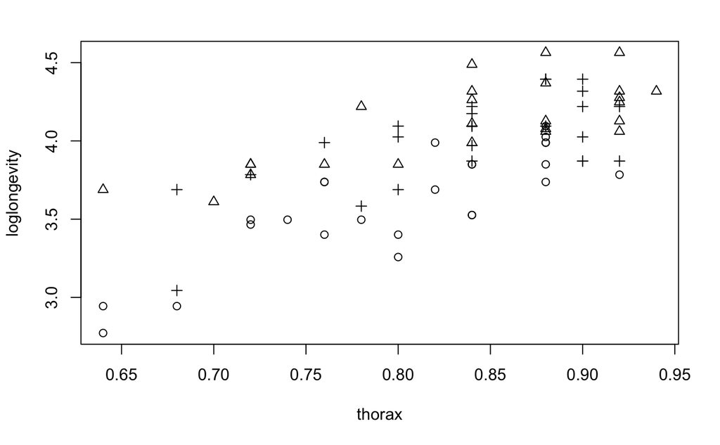

```r
plot(loglongevity~thorax,pch=unclass(activity),data = fruitflies)
```

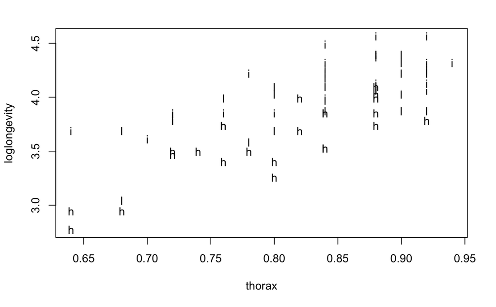

```r
plot(loglongevity~thorax,pch=as.character(activity),data = fruitflies)
```

### 3. Investigate whether sexual activity influences longevity by performing a statistical test, without taking the thorax length into account.

```r
fit1 = lm(loglongevity~activity,data=fruitflies)
anova(fit1)
```

```
Analysis of Variance Table

Response: loglongevity
          Df Sum Sq Mean Sq F value    Pr(>F)
activity   2 3.6665  1.8333  19.421 1.798e-07 ***
Residuals 72 6.7966  0.0944
---
Signif. codes:  0 ‘***’ 0.001 ‘**’ 0.01 ‘*’ 0.05 ‘.’ 0.1 ‘ ’ 1
```

### 4. Does sexual activity increase or decrease longevity? What are the estima- ted longevities for the three conditions? To answer these questions, use the analysis as under 3), without taking thorax length into account.

### 5. Investigate whether sexual activity influences longevity by performing a statistical test, now including thorax length as an explanatory variable into the analysis.

```r
fit2= lm(longevity~activity+thorax,data=fruitflies)
anova(fit2)
```

```
Analysis of Variance Table

Response: longevity
          Df Sum Sq Mean Sq F value    Pr(>F)
activity   2 8239.2  4119.6  38.120 5.686e-12 ***
thorax     1 7686.8  7686.8  71.127 2.624e-12 ***
Residuals 71 7673.0   108.1
---
Signif. codes:  0 ‘***’ 0.001 ‘**’ 0.01 ‘*’ 0.05 ‘.’ 0.1 ‘ ’ 1
```

### 6. Does sexual activity increase or decrease longevity? What are the esti- mated longevities for the three conditions, for a fly with average thorax length? And what are they for a typical fly as small as the smallest in the data set? To answer these questions, use the analysis as under 5), which includes thorax length.

### 7. How does thorax length influence longevity? Graphically investigate whe- ther this dependence is similar under all three conditions of sexual activity.

```r
plot(longevity~thorax,pch=unclass(activity))
abline(lm(longevity~thorax,data=fruitflies[fruitflies$activity=='isolated',]))
```

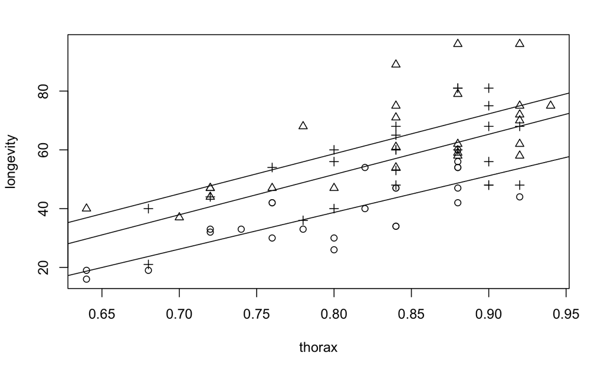

```r
abline(lm(longevity~thorax,data=fruitflies[fruitflies$activity=='low',]))
abline(lm(longevity~thorax,data=fruitflies[fruitflies$activity=='high',]))
```

### 8. Which of the two analyses, without or with thorax length, do you prefer? Is one of the analyses wrong? (To answer the last question, carefully (re)read the description of the design of the experiment.)

### 9. Verify normality and heteroscedasticity by making a normal QQ-plot of the residuals, and a residuals versus fitted plot, for the analysis that in- cludes thorax length.

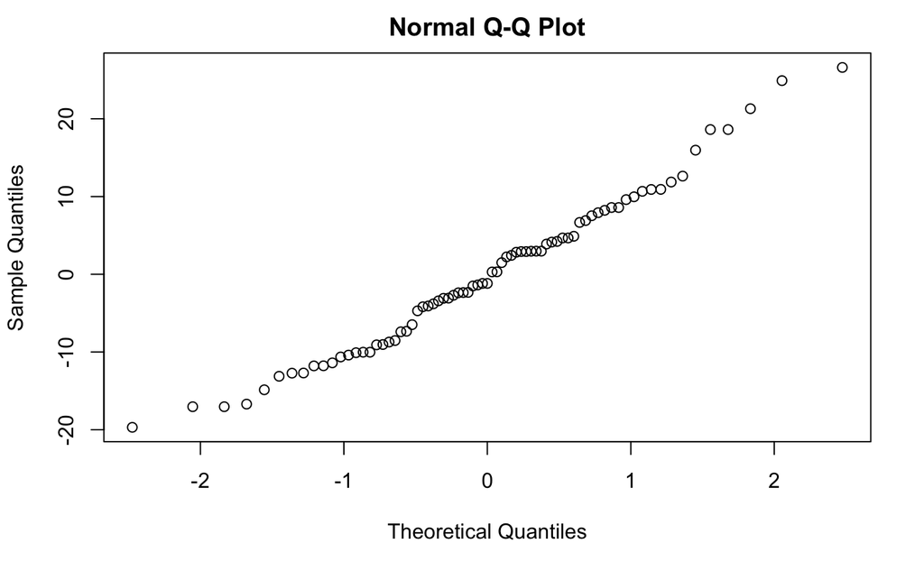

```r
qqnorm(residuals(fit2))
```

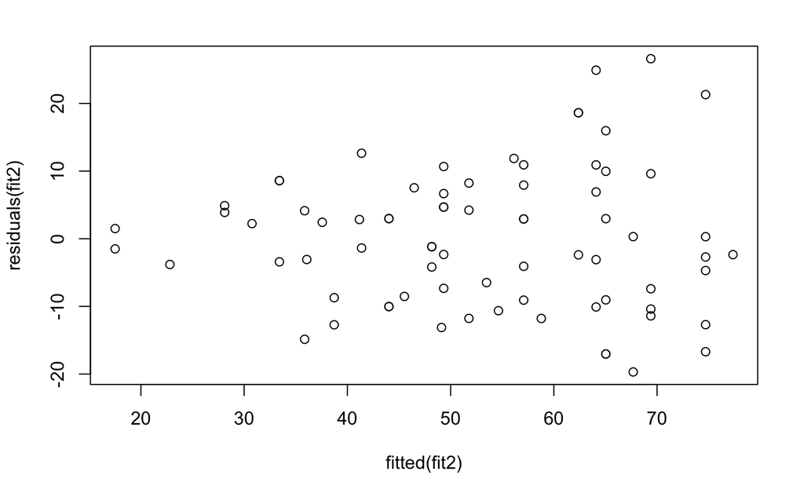

```r
plot(fitted(fit2),residuals(fit2))
```

### 10. Perform the ancova analysis with the number of days as the outcome, rather than its logarithm. Verify normality and heteroscedasticity of the residuals of this analysis. Was it wise to use the logarithm as outcome?

## EXERCISE 2

```r
psi_data = read.table('psi.txt',header = TRUE)
```

To study the effect of a new teaching method called “personalized system of instruction” (psi), 32 students were randomized to either receive psi or to be taught using the existing method. At the end of the teaching period the success of the teaching method was assessed by giving the students a difficult assign- ment, which they could pass or not. The average grade of the students (gpa on a scale of 0–4, with 4 being the best grade) were also available for analysis. The data can be found in the file psi.txt. ###1. Study the data and give a few (> 1) summaries (graphics or tables).

```r
summary(psi_data)
```

```
     passed            psi              gpa
 Min.   :0.0000   Min.   :0.0000   Min.   :2.060
 1st Qu.:0.0000   1st Qu.:0.0000   1st Qu.:2.812
 Median :0.0000   Median :0.0000   Median :3.065
 Mean   :0.3438   Mean   :0.4375   Mean   :3.117
 3rd Qu.:1.0000   3rd Qu.:1.0000   3rd Qu.:3.515
 Max.   :1.0000   Max.   :1.0000   Max.   :4.000
```

```r
tot=xtabs(~gpa+psi,data=psi_data); tot
```

```
      psi
gpa    0 1
  2.06 0 1
  2.39 0 1
  2.63 1 0
  2.66 1 0
  2.67 0 1
  2.74 1 0
  2.75 1 0
  2.76 1 0
  2.83 1 1
  2.86 1 0
  2.87 1 0
  2.89 1 1
  2.92 1 0
  3.03 1 0
  3.1  0 1
  3.12 0 1
  3.16 0 1
  3.26 1 0
  3.28 1 0
  3.32 1 0
  3.39 0 1
  3.51 0 1
  3.53 1 0
  3.54 0 1
  3.57 1 0
  3.62 0 1
  3.65 0 1
  3.92 1 0
  4    1 1
```

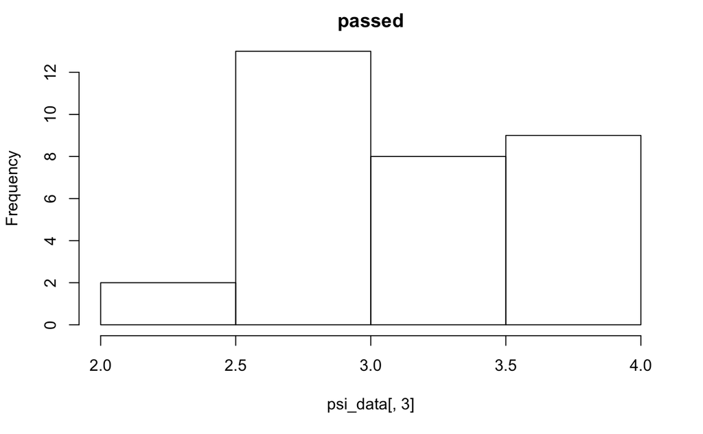

```r
hist(psi_data[,3],main='passed')
```

```r
 round(xtabs(passed~gpa+psi,data=psi_data)/tot,2)
```

```
      psi
gpa      0   1
  2.06       0
  2.39       1
  2.63   0
  2.66   0
  2.67       0
  2.74   0
  2.75   0
  2.76   0
  2.83   0   1
  2.86   0
  2.87   0
  2.89   0   0
  2.92   0
  3.03   0
  3.1        0
  3.12       0
  3.16       1
  3.26   1
  3.28   0
  3.32   0
  3.39       1
  3.51       0
  3.53   0
  3.54       1
  3.57   0
  3.62       1
  3.65       1
  3.92   1
  4      1   1
```

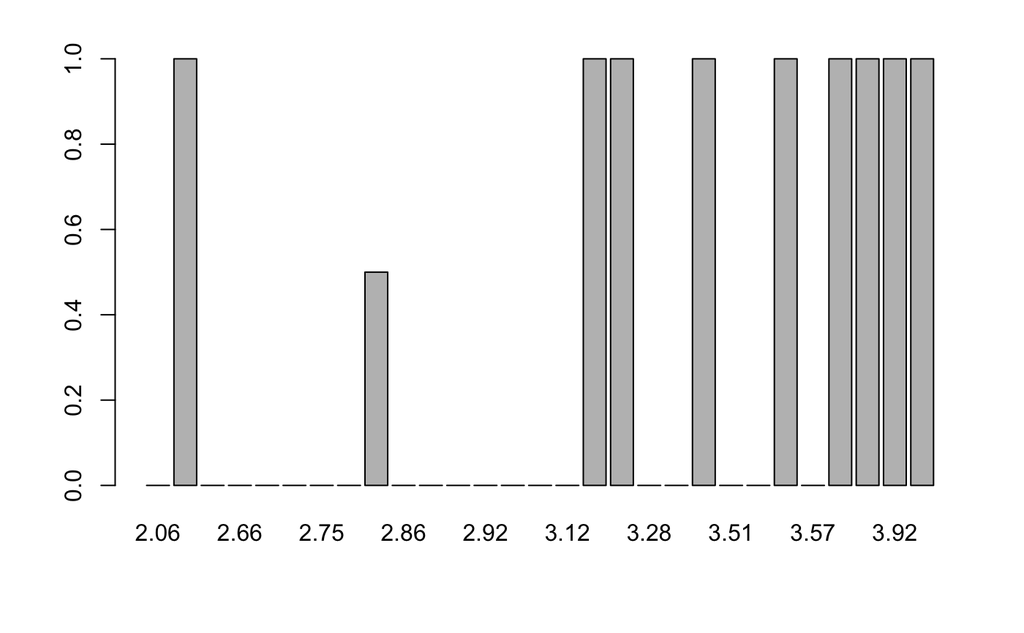

```r
totgpa=xtabs(~gpa,data=psi_data)
barplot(xtabs(passed~gpa,data=psi_data)/totgpa)
```

### 2. Fit a logistic regression model with both explanatory variables.

```r
psi_data$gpa2=psi_data$gpa^2
psiglm=glm(passed~gpa+gpa2+psi,data=psi_data,family=binomial)
summary(psiglm)
```

```
Call:
glm(formula = passed ~ gpa + gpa2 + psi, family = binomial, data = psi_data)

Deviance Residuals:
    Min       1Q   Median       3Q      Max
-1.8183  -0.5737  -0.2500   0.4733   2.1584

Coefficients:
            Estimate Std. Error z value Pr(>|z|)
(Intercept)   14.050     16.462   0.854   0.3934
gpa          -13.893     11.048  -1.258   0.2086
gpa2           2.730      1.830   1.492   0.1356
psi            2.520      1.179   2.137   0.0326 *
---
Signif. codes:  0 ‘***’ 0.001 ‘**’ 0.01 ‘*’ 0.05 ‘.’ 0.1 ‘ ’ 1

(Dispersion parameter for binomial family taken to be 1)

    Null deviance: 41.183  on 31  degrees of freedom
Residual deviance: 24.007  on 28  degrees of freedom
AIC: 32.007

Number of Fisher Scoring iterations: 5
```

```r
psi_data$gpa=factor(psi_data$gpa)
psi_data$psi=factor(psi_data$psi)
psi_data$passed=factor(psi_data$passed)
psiglm2=glm(passed~gpa+psi,data=psi_data,family=binomial)
```

```
glm.fit: fitted probabilities numerically 0 or 1 occurred
```

```r
summary(psiglm2)
```

```
Call:
glm(formula = passed ~ gpa + psi, family = binomial, data = psi_data)

Deviance Residuals:
         1           2           3           4           5           6           7           8           9          10
-2.409e-06  -2.110e-08  -2.409e-06  -2.409e-06   4.193e-06  -2.409e-06  -2.409e-06  -2.409e-06  -2.409e-06   2.409e-06
        11          12          13          14          15          16          17          18          19          20
-2.409e-06  -2.409e-06  -2.409e-06   2.409e-06  -2.409e-06  -2.409e-06  -2.409e-06  -5.576e-06  -2.409e-06   2.409e-06
        21          22          23          24          25          26          27          28          29          30
-2.409e-06   2.409e-06  -4.193e-06  -2.409e-06   2.409e-06   5.576e-06   2.409e-06  -2.409e-06   2.409e-06   2.110e-08
        31          32
-2.409e-06   2.409e-06

Coefficients:
              Estimate Std. Error z value Pr(>|z|)
(Intercept) -7.634e+01  4.173e+05       0        1
gpa2.39      5.313e+01  5.036e+05       0        1
gpa2.63      4.977e+01  5.486e+05       0        1
gpa2.66      4.977e+01  5.486e+05       0        1
gpa2.67     -8.295e-14  5.036e+05       0        1
gpa2.74      4.977e+01  5.486e+05       0        1
gpa2.75      4.977e+01  5.486e+05       0        1
gpa2.76      4.977e+01  5.486e+05       0        1
gpa2.83      5.145e+01  3.879e+05       0        1
gpa2.86      4.977e+01  5.486e+05       0        1
gpa2.87      4.977e+01  5.486e+05       0        1
gpa2.89      1.109e+00  4.107e+05       0        1
gpa2.92      4.977e+01  5.486e+05       0        1
gpa3.03      4.977e+01  5.486e+05       0        1
gpa3.1      -9.658e-14  5.036e+05       0        1
gpa3.12     -1.331e-13  5.036e+05       0        1
gpa3.16      5.313e+01  5.036e+05       0        1
gpa3.26      1.029e+02  5.486e+05       0        1
gpa3.28      4.977e+01  5.486e+05       0        1
gpa3.32      4.977e+01  5.486e+05       0        1
gpa3.39      5.313e+01  5.036e+05       0        1
gpa3.51     -1.164e-13  5.036e+05       0        1
gpa3.53      4.977e+01  5.486e+05       0        1
gpa3.54      5.313e+01  5.036e+05       0        1
gpa3.57      4.977e+01  5.486e+05       0        1
gpa3.62      5.313e+01  5.036e+05       0        1
gpa3.65      5.313e+01  5.036e+05       0        1
gpa3.92      1.029e+02  5.486e+05       0        1
gpa4         1.018e+02  4.648e+05       0        1
psi1         4.977e+01  2.176e+05       0        1

(Dispersion parameter for binomial family taken to be 1)

    Null deviance: 4.1183e+01  on 31  degrees of freedom
Residual deviance: 2.4819e-10  on  2  degrees of freedom
AIC: 60

Number of Fisher Scoring iterations: 25
```

### 3. Does psi work?

### 4. Estimate the probability that a student with a gpa equal to 3 who receives psi passes the assignment. Estimate the same probability for a student who does not receive psi.

```r
# plot(c(0,coef(psiglm2)[13:27]),type="l")
psi_data$gpa <- as.numeric(psi_data$gpa)
psiglm=glm(passed~gpa+psi,data=psi_data,family=binomial)
gpa3passed=data.frame(psi=factor(1),gpa=3)
predict.glm(psiglm,gpa3passed,type="response")
```

```
        1
0.1505314
```

the passing factor with gpa 3

```r
gpa3failed=data.frame(psi=factor(0),gpa=3)
predict.glm(psiglm,gpa3failed,type="response")
```

```
        1
0.0194262
```

### 5. Estimate the relative change in odds of passing the assignment rendered by instructing students with psi rather than the standard method (for an arbitrary student). What is the interpretation of this number? Is it dependent on gpa?

Consider the following alternative method of analysis. Out of 18 students who did not receive psi 3 showed improvement, of the 14 remaining students 8 showed improvement. We perform a test for comparing two binomial propor- tions: we have two sequences of independent binary “experiments”, of lengths 18 and 14. The experiments in the first sequence have success probability p1, those in the second p2. We wish to test the null hypothesis H0 : p1 = p2 using the observed numbers of successes 3 and 8. You can find the test (Fisher’s exact test or the chisquare test for a 2x2 table) in your introductory statistics book (or see e.g. Dalgaard, section 7.2). In R you can simply type: x=matrix(c(3,15,8,6),2,2) x [,1] [,2] [1,] 3 8 [2,] 15 6 fisher.test(x) ###6. Do this. What are the numbers 15 and 6 in this table? What is the conclusion?

```r
x=matrix(c(3,15,8,6),2,2)
x
```

```
     [,1] [,2]
[1,]    3    8
[2,]   15    6
```

```r
fisher.test(x)
```

```
    Fisher's Exact Test for Count Data

data:  x
p-value = 0.0265
alternative hypothesis: true odds ratio is not equal to 1
95 percent confidence interval:
 0.02016297 0.95505763
sample estimates:
odds ratio
 0.1605805
```

### 7. Given the way the experiment was conducted, is this second approach wrong? Why or why not?

### 8. Name both an advantage and a disadvantage of the two approaches, rela- tive to each other.

## EXERCISE 3

```r
africa = read.table('africa.txt',header = TRUE)
```

To study the influence of different political and geographical variables on the number of military coups, these data are collected for several Sub Saharan Af- rican countries in the file africa.txt. The meaning of the different variables is miltcoup — number of successful military coups from independence to 1989 oligarchy — number years country ruled by military oligarchy from indepen- dence to 1989 pollib — Political liberalization (0 = no civil rights for political expression, 1 = limited civil rights for expression but right to form political parties, 2 = full civil rights) parties — Number of legal political parties in 1993 pctvote — Percent voting in last election popn — Population in millions in 1989 size — Area in 1000 square km numelec — Total number of legislative and presidential elections numregim — Number of regime types In this exercise you will fit a regression model to these data using Poisson regression, but first Poisson distributions are studied. ###1. Study (graphically) some different Poisson distributions using Poisson samples generated by rpois(n,lambda), varying both n and (positive) lambda.

```r
par(mfrow=c(4,4))
hist(rpois(10,0.5))
hist(rpois(10,5))
```

```r
hist(rpois(10,100))
hist(rpois(10,1000))
```

```r
hist(rpois(100,0.5))
hist(rpois(100,5))
```

```r
hist(rpois(100,100))
hist(rpois(100,1000))
```

```r
hist(rpois(1000,0.5))
hist(rpois(1000,5))
```

```r
hist(rpois(1000,100))
hist(rpois(1000,1000))
```

```r
hist(rpois(10000,0.5))
hist(rpois(10000,5))
```

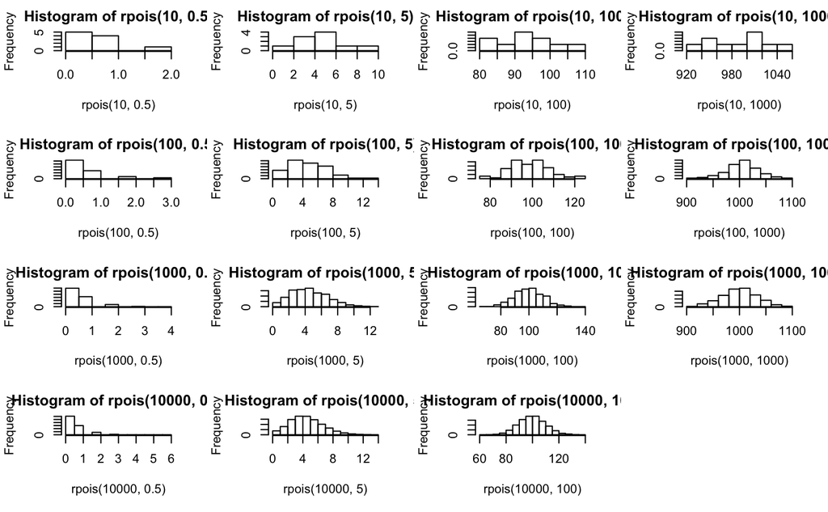

```r
hist(rpois(10000,100))
hist(rpois(10000,1000))
```

### 2. Two distributions are in the same location-scale family if there is a scale- and-shift transformation that maps one to the other. Investigate whether different Poisson distributions are in the same location-scale family, like all normal distribution. Clearly explain your approach to this question, and your answer.

### 3. Perform Poisson regression on the full africa data, taking miltcoup as response variable.

```r
africaglm_all=glm(miltcoup~oligarchy+ pollib+parties+pctvote+popn+size+numelec+numregim,family=poisson,data=africa)
summary(africaglm_all)
```

```
Call:
glm(formula = miltcoup ~ oligarchy + pollib + parties + pctvote +
    popn + size + numelec + numregim, family = poisson, data = africa)

Deviance Residuals:
    Min       1Q   Median       3Q      Max
-1.3443  -0.9542  -0.2587   0.3905   1.6953

Coefficients:
              Estimate Std. Error z value Pr(>|z|)
(Intercept) -0.5102693  0.9053301  -0.564  0.57301
oligarchy    0.0730814  0.0345958   2.112  0.03465 *
pollib      -0.7129779  0.2725635  -2.616  0.00890 **
parties      0.0307739  0.0111873   2.751  0.00595 **
pctvote      0.0138722  0.0097526   1.422  0.15491
popn         0.0093429  0.0065950   1.417  0.15658
size        -0.0001900  0.0002485  -0.765  0.44447
numelec     -0.0160783  0.0654842  -0.246  0.80605
numregim     0.1917349  0.2292890   0.836  0.40303
---
Signif. codes:  0 ‘***’ 0.001 ‘**’ 0.01 ‘*’ 0.05 ‘.’ 0.1 ‘ ’ 1

(Dispersion parameter for poisson family taken to be 1)

    Null deviance: 65.945  on 35  degrees of freedom
Residual deviance: 28.668  on 27  degrees of freedom
AIC: 111.48

Number of Fisher Scoring iterations: 6
```

### 4. Use the step down approach (using output of the function summary) to reduce the number of explanatory variables.

```r
africaglm=glm(miltcoup~oligarchy+ pollib+parties+pctvote+popn+size+numregim,family=poisson,data=africa)
summary(africaglm)
```

```
Call:
glm(formula = miltcoup ~ oligarchy + pollib + parties + pctvote +
    popn + size + numregim, family = poisson, data = africa)

Deviance Residuals:
    Min       1Q   Median       3Q      Max
-1.3997  -0.9381  -0.2666   0.4220   1.6998

Coefficients:
              Estimate Std. Error z value Pr(>|z|)
(Intercept) -0.6078028  0.8239267  -0.738  0.46070
oligarchy    0.0781368  0.0277656   2.814  0.00489 **
pollib      -0.6773897  0.2290130  -2.958  0.00310 **
parties      0.0296786  0.0102888   2.885  0.00392 **
pctvote      0.0131290  0.0092895   1.413  0.15756
popn         0.0089313  0.0063746   1.401  0.16120
size        -0.0002021  0.0002436  -0.830  0.40682
numregim     0.1758198  0.2210498   0.795  0.42639
---
Signif. codes:  0 ‘***’ 0.001 ‘**’ 0.01 ‘*’ 0.05 ‘.’ 0.1 ‘ ’ 1

(Dispersion parameter for poisson family taken to be 1)

    Null deviance: 65.945  on 35  degrees of freedom
Residual deviance: 28.728  on 28  degrees of freedom
AIC: 109.54

Number of Fisher Scoring iterations: 5
```

```r
africaglm=glm(miltcoup~oligarchy+ pollib+parties+pctvote+popn+size,family=poisson,data=africa)
summary(africaglm)
```

```
Call:
glm(formula = miltcoup ~ oligarchy + pollib + parties + pctvote +
    popn + size, family = poisson, data = africa)

Deviance Residuals:
    Min       1Q   Median       3Q      Max
-1.3522  -0.9651  -0.1945   0.4833   1.6179

Coefficients:
              Estimate Std. Error z value Pr(>|z|)
(Intercept) -0.1126871  0.5163030  -0.218 0.827228
oligarchy    0.0859620  0.0259100   3.318 0.000908 ***
pollib      -0.6894029  0.2278572  -3.026 0.002481 **
parties      0.0291944  0.0101954   2.863 0.004190 **
pctvote      0.0141588  0.0091980   1.539 0.123723
popn         0.0062736  0.0053994   1.162 0.245272
size        -0.0001950  0.0002425  -0.804 0.421378
---
Signif. codes:  0 ‘***’ 0.001 ‘**’ 0.01 ‘*’ 0.05 ‘.’ 0.1 ‘ ’ 1

(Dispersion parameter for poisson family taken to be 1)

    Null deviance: 65.945  on 35  degrees of freedom
Residual deviance: 29.363  on 29  degrees of freedom
AIC: 108.17

Number of Fisher Scoring iterations: 5
```

```r
africaglm=glm(miltcoup~oligarchy+ pollib+parties+pctvote+popn,family=poisson,data=africa)
summary(africaglm)
```

```
Call:
glm(formula = miltcoup ~ oligarchy + pollib + parties + pctvote +
    popn, family = poisson, data = africa)

Deviance Residuals:
    Min       1Q   Median       3Q      Max
-1.4109  -0.9943  -0.1399   0.5516   1.6125

Coefficients:
             Estimate Std. Error z value Pr(>|z|)
(Intercept) -0.244466   0.495708  -0.493  0.62190
oligarchy    0.083168   0.025437   3.270  0.00108 **
pollib      -0.652830   0.221234  -2.951  0.00317 **
parties      0.029800   0.010294   2.895  0.00379 **
pctvote      0.013842   0.009282   1.491  0.13591
popn         0.005587   0.005378   1.039  0.29883
---
Signif. codes:  0 ‘***’ 0.001 ‘**’ 0.01 ‘*’ 0.05 ‘.’ 0.1 ‘ ’ 1

(Dispersion parameter for poisson family taken to be 1)

    Null deviance: 65.945  on 35  degrees of freedom
Residual deviance: 30.044  on 30  degrees of freedom
AIC: 106.85

Number of Fisher Scoring iterations: 5
```

```r
africaglm=glm(miltcoup~oligarchy+ pollib+parties+pctvote,family=poisson,data=africa)
summary(africaglm)
```

```
Call:
glm(formula = miltcoup ~ oligarchy + pollib + parties + pctvote,
    family = poisson, data = africa)

Deviance Residuals:
    Min       1Q   Median       3Q      Max
-1.5456  -0.9841  -0.1881   0.5948   1.6705

Coefficients:
             Estimate Std. Error z value Pr(>|z|)
(Intercept) -0.093657   0.463279  -0.202  0.83979
oligarchy    0.095358   0.022421   4.253 2.11e-05 ***
pollib      -0.666615   0.217564  -3.064  0.00218 **
parties      0.025630   0.009502   2.697  0.00699 **
pctvote      0.012134   0.009056   1.340  0.18031
---
Signif. codes:  0 ‘***’ 0.001 ‘**’ 0.01 ‘*’ 0.05 ‘.’ 0.1 ‘ ’ 1

(Dispersion parameter for poisson family taken to be 1)

    Null deviance: 65.945  on 35  degrees of freedom
Residual deviance: 31.081  on 31  degrees of freedom
AIC: 105.89

Number of Fisher Scoring iterations: 5
```

```r
africaglm=glm(miltcoup~oligarchy+ pollib+parties,family=poisson,data=africa)
summary(africaglm)
```

```
Call:
glm(formula = miltcoup ~ oligarchy + pollib + parties, family = poisson,
    data = africa)

Deviance Residuals:
    Min       1Q   Median       3Q      Max
-1.3583  -1.0424  -0.2863   0.6278   1.7517

Coefficients:
             Estimate Std. Error z value Pr(>|z|)
(Intercept)  0.251377   0.372689   0.674  0.50000
oligarchy    0.092622   0.021779   4.253 2.11e-05 ***
pollib      -0.574103   0.204383  -2.809  0.00497 **
parties      0.022059   0.008955   2.463  0.01377 *
---
Signif. codes:  0 ‘***’ 0.001 ‘**’ 0.01 ‘*’ 0.05 ‘.’ 0.1 ‘ ’ 1

(Dispersion parameter for poisson family taken to be 1)

    Null deviance: 65.945  on 35  degrees of freedom
Residual deviance: 32.856  on 32  degrees of freedom
AIC: 105.66

Number of Fisher Scoring iterations: 5
```

### 5. Make one or more diagnostic plots of the deviance residuals for the model you have found in part (4). In case you see a certain pattern, check whether that is also present in the full model (using all explanatory variables), i.e. see whether is it due to deleting too many variables. Comment on the pattern (if possible).

```r
par(mfrow=c(3,2))
plot(fitted(africaglm),residuals(africaglm))
plot(fitted(africaglm_all),residuals(africaglm_all))
```

```r
plot(log(fitted(africaglm)),residuals(africaglm))
plot(log(fitted(africaglm_all)),residuals(africaglm_all))
```

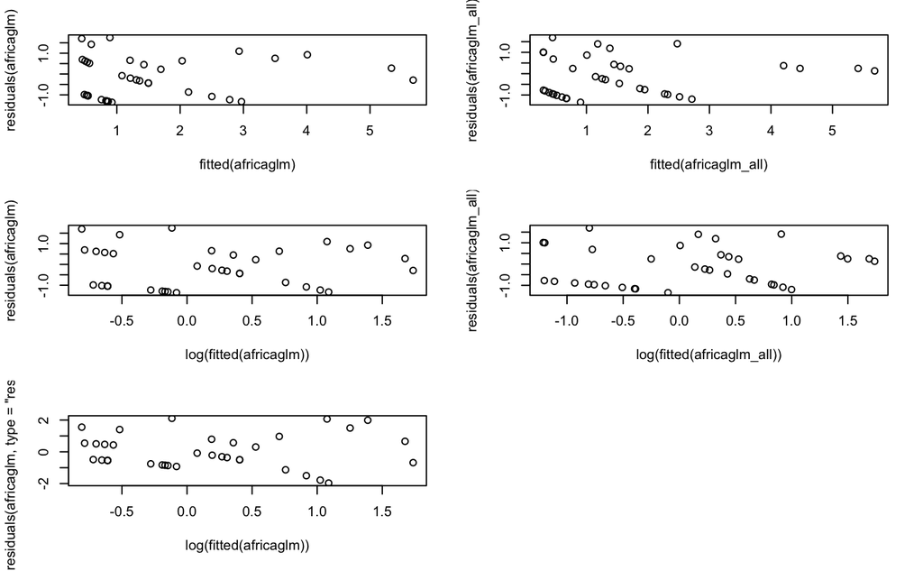

```r
plot(log(fitted(africaglm)),residuals(africaglm,type="response"))
plot(log(fitted(africaglm_all)),residuals(africaglm_all,type="response"))
```